# lab1

Husain Agha

3/26/2020

1. What are the median amounts of the top ten pesticides (high estimate usage)?

```r
pest.total %>% group_by(COMPOUND) %>%
  summarise(medians = median(HIGH_ESTIMATE)) %>%
  arrange(desc(medians))
```

```
## # A tibble: 413 x 2
##    COMPOUND                medians
##    <chr>                     <dbl>
##  1 Glyphosate               15234
##  2 Propanil                  3175.
##  3 2,4-D                     2997.
##  4 Atrazine                  2354.
##  5 Metolachlor-S             2323.
##  6 Petroleum Distillate      2126.
##  7 Dichloropropene           1673.
##  8 Acetochlor                1382.
##  9 Pendimethalin             1149.
## 10 Copper Sulfate TrIBAsic    793.
## # … with 403 more rows
```

2. Which pesticide has the largest total usage over the two year period? In which state was this pesticide used the most? In which state was it used the least?

```r
pest.total %>%
  group_by(COMPOUND) %>%
  summarise(total = sum(HIGH_ESTIMATE)) %>%
  filter(total == max(total))
```

```
## # A tibble: 1 x 2
##   COMPOUND        total
##   <chr>           <dbl>
## 1 Glyphosate 256317246.
```

```r
pest.total %>%
  filter(COMPOUND == "Glyphosate") %>%
  group_by(STATE_CODE) %>%
  summarise(usage.by.state = sum(HIGH_ESTIMATE)) %>%
  filter(usage.by.state == max(usage.by.state) | usage.by.state == min(usage.by.state))
```

```
## # A tibble: 2 x 2
##   STATE_CODE usage.by.state
##   <chr>               <dbl>
## 1 19              22965254.
## 2 44                  1616.
```

3. Which state has the least average percentage difference between the high and low estimates of the reported pesticide usage? Entries with no low etimates should be excluded.

```r
pest.total %>%
  filter(!is.na(LOW_ESTIMATE)) %>%
  group_by(STATE_CODE) %>%
  summarise(sum.high = sum(HIGH_ESTIMATE), sum.low = sum(LOW_ESTIMATE)) %>%
  mutate(mean_est = mean(c(sum.high, sum.low)),
         abs.difference = sum.high - sum.low,
         perc.difference = (100*abs.difference/mean_est)) %>%
  filter(perc.difference == max(perc.difference))
```

```
## # A tibble: 1 x 6
##   STATE_CODE  sum.high   sum.low  mean_est abs.difference perc.difference
##   <chr>          <dbl>     <dbl>     <dbl>          <dbl>           <dbl>
## 1 53         49518694. 44478192. 16960954.       5040502.            29.7
```

4. Which state(s) used the most number of pesticides? How many pesticides did that (those) state(s) use?

```r
pest.total %>%
  group_by(STATE_CODE) %>%
  distinct(COMPOUND, .keep_all = T) %>%
  summarise(totals = n()) %>%
  filter(totals == max(totals))
```

```
## # A tibble: 1 x 2
##   STATE_CODE totals
##   <chr>       <int>
## 1 06            311
```

5. Which county used the largest amount of pesticides? What state is that county in?

```r
pest.total %>%
  group_by(STATE_CODE, COUNTY_CODE) %>%
  summarise(pest.use = sum(HIGH_ESTIMATE)) %>%
  ungroup() %>%
  filter(pest.use == max(pest.use))
```

```
## # A tibble: 1 x 3
##   STATE_CODE COUNTY_CODE  pest.use
##   <chr>      <chr>           <dbl>
## 1 53         025         12456589.
```

6. Which state(s) have the largest number of counties? What was the number of counties in that (those) states?

```r
pest.total %>%
  group_by(STATE_CODE) %>%
  distinct(COUNTY_CODE, .keep_all = T) %>%
  summarise(num.counties = n()) %>%
  ungroup() %>%
  filter(num.counties == max(num.counties))
```

```
## # A tibble: 1 x 2
##   STATE_CODE num.counties
##   <chr>             <int>
## 1 48                  254
```

7. List the top ten states with the largest total median usage per number of counties grouped by year

```r
top.usage.per.county <- pest.total %>%
  group_by(YEAR, STATE_CODE) %>%
  distinct(COUNTY_CODE, .keep_all = T) %>%
  summarise(n.county = n(), total_usage = sum(HIGH_ESTIMATE), usage.per.county = total_usage/n.county) %>%
  distinct(STATE_CODE, .keep_all = T) %>%
  arrange(desc(usage.per.county)) %>%
  ungroup() %>% group_split(YEAR)

top.usage.per.county[[1]][1:10,]
```

```
## # A tibble: 10 x 5
##     YEAR STATE_CODE n.county total_usage usage.per.county
##    <dbl> <chr>         <int>       <dbl>            <dbl>
##  1  2014 20              105    1947933.           18552.
##  2  2014 40               77    1168280.           15172.
##  3  2014 31               93    1259264.           13540.
##  4  2014 18               92     995752            10823.
##  5  2014 30               56     588824.           10515.
##  6  2014 22               64     634826.            9919.
##  7  2014 17              102     989555.            9702.
##  8  2014 38               53     513325.            9685.
##  9  2014 10                3      28728.            9576.
## 10  2014 05               74     688082.            9298.
```

```r
top.usage.per.county[[2]][1:10,]
```

```
## # A tibble: 10 x 5
##     YEAR STATE_CODE n.county total_usage usage.per.county
##    <dbl> <chr>         <int>       <dbl>            <dbl>
##  1  2015 20              105    2510184.           23907.
##  2  2015 30               56     850322            15184.
##  3  2015 31               93    1302722            14008.
##  4  2015 40               77     995116.           12924.
##  5  2015 08               63     720179.           11431.
##  6  2015 22               64     718325.           11224.
##  7  2015 18               92     963865            10477.
##  8  2015 10                3      31423            10474.
##  9  2015 05               74     765401.           10343.
## 10  2015 46               66     657334.            9960.
```

```r
rm(top.usage.per.county)
```

8. List the top five states with the largest amount/no. of pesticides grouped by year?

```r
pest.total %>%
  group_by(STATE_CODE, YEAR) %>%
  summarise(usage = sum(HIGH_ESTIMATE)) %>%
  arrange(desc(usage)) %>%
  ungroup() %>% group_split(YEAR)
```

```
## [[1]]
## # A tibble: 48 x 3
##    STATE_CODE  YEAR     usage
##    <chr>      <dbl>     <dbl>
##  1 06          2014 59524168.
##  2 19          2014 27853530.
##  3 17          2014 26555737.
##  4 12          2014 26304902.
##  5 53          2014 26186833.
##  6 20          2014 21181997.
##  7 31          2014 21040188.
##  8 48          2014 20834488
##  9 16          2014 18314143.
## 10 13          2014 16640122.
## # … with 38 more rows
##
## [[2]]
## # A tibble: 47 x 3
##    STATE_CODE  YEAR     usage
##    <chr>      <dbl>     <dbl>
##  1 53          2015 27771168.
##  2 12          2015 27206445.
##  3 17          2015 27179762.
##  4 19          2015 26496214.
##  5 20          2015 25248883.
##  6 48          2015 23358474.
##  7 31          2015 20378125.
##  8 27          2015 17152120
##  9 16          2015 15933677.
## 10 38          2015 15615178.
## # … with 37 more rows
##
## attr(,"ptype")
## # A tibble: 0 x 3
## # … with 3 variables: STATE_CODE <chr>, YEAR <dbl>, usage <dbl>
```

```r
pest.total %>%
  group_by(STATE_CODE, YEAR) %>%
  distinct(COMPOUND, .keep_all = T) %>%
  summarise(no.pest = n()) %>%
  arrange(desc(no.pest)) %>%
  ungroup() %>% group_split(YEAR)
```

```
## [[1]]
## # A tibble: 48 x 3
##    STATE_CODE  YEAR no.pest
##    <chr>      <dbl>   <int>
##  1 06          2014     311
##  2 41          2014     232
##  3 53          2014     225
##  4 13          2014     218
##  5 12          2014     217
##  6 16          2014     216
##  7 51          2014     216
##  8 26          2014     213
##  9 37          2014     213
## 10 48          2014     213
## # … with 38 more rows
##
## [[2]]
## # A tibble: 47 x 3
##    STATE_CODE  YEAR no.pest
##    <chr>      <dbl>   <int>
##  1 53          2015     235
##  2 41          2015     231
##  3 32          2015     212
##  4 13          2015     210
##  5 12          2015     209
##  6 48          2015     207
##  7 04          2015     206
##  8 37          2015     204
##  9 26          2015     203
## 10 16          2015     202
## # … with 37 more rows
##
## attr(,"ptype")
## # A tibble: 0 x 3
## # … with 3 variables: STATE_CODE <chr>, YEAR <dbl>, no.pest <int>
```

9. List the top five states by largest median usage of chemicals

```r
pest.total %>% group_by(COMPOUND, STATE_CODE) %>%
  summarise(total.per.compound = sum(HIGH_ESTIMATE)) %>%
  ungroup() %>%
  group_by(STATE_CODE) %>%
  summarise(medians = median(total.per.compound)) %>%
  arrange(desc(medians))
```

```
## # A tibble: 48 x 2
##    STATE_CODE medians
##    <chr>        <dbl>
##  1 38          11316.
##  2 31           9514.
##  3 53           6904
##  4 12           6648.
##  5 48           6643
##  6 05           6506.
##  7 19           6496.
##  8 46           6475.
##  9 06           6038.
## 10 17           5994.
## # … with 38 more rows
```

10. Which pesticide was used in the most number of states?

```r
pest.total %>%
  distinct(STATE_CODE, COMPOUND, .keep_all = T) %>%
  filter(HIGH_ESTIMATE > 0) %>%
  group_by(COMPOUND) %>%
  tally() %>%
  arrange(desc(n))
```

```
## # A tibble: 403 x 2
##    COMPOUND          n
##    <chr>         <int>
##  1 2,4-D            48
##  2 Atrazine         48
##  3 Bentazone        48
##  4 Chlorpyrifos     48
##  5 Dicamba          48
##  6 Glyphosate       48
##  7 Mancozeb         48
##  8 Metolachlor-S    48
##  9 Metribuzin       48
## 10 Paraquat         48
## # … with 393 more rows
```

11. What pesticide has the largest percentage increase in the number of states using it from 2014 to 2015?

```r
comp.by.year <- pest.total %>%
  distinct(STATE_CODE, COMPOUND, .keep_all = T) %>%
  group_by(COMPOUND, YEAR) %>%
  tally() %>% ungroup() %>%
  group_split(YEAR)

comp.by.year[[2]]$COMPOUND[which(!comp.by.year[[2]]$COMPOUND %in% comp.by.year[[1]]$COMPOUND)]
```

```
##  [1] "1-Methyl Cyclopropene"     "Allyl Isothiocyanate"
##  [3] "Aspergillus Flavus"        "Aureobasidium Pullulans"
##  [5] "Bicyclopyrone"             "Burkholderia Spp"
##  [7] "Chenopodium Ambrosioides"  "Chromobacterium Subtsugae"
##  [9] "Cyantraniliprole"          "Cyflumetofen"
## [11] "Fenazaquin"                "Ferbam"
## [13] "Flazasulfuron"             "Flupyradifurone"
## [15] "Fluridone"                 "Gliocladium Virens"
## [17] "Imazamethabenz"            "Isaria Fumosorosea"
## [19] "Isofetamid"                "Paecilomyces Lilacinus"
## [21] "Polyoxorim"                "Reynoutria Sachalinensis"
## [23] "Streptomyces Lydicus"      "Sucrose Octanoate"
## [25] "Tolfenpyrad"
```

12. List the top five states with the largest increase in median usage of pesticides from 2014 to 2015

```r
year.state.medians <- pest.total %>% group_by(STATE_CODE, YEAR) %>%
  summarise(medians = median(HIGH_ESTIMATE)) %>%
  ungroup() %>%
  add_case(STATE_CODE = 6, YEAR = 2015, medians = 0) %>%
  arrange(STATE_CODE) %>% group_split(YEAR)

diff <- data.frame(medians = year.state.medians[[2]]$medians - year.state.medians[[1]]$medians)
diff$STATE_CODE <- year.state.medians[[1]]$STATE_CODE
diff$STATE_CODE[which.max(diff$medians)]
```

```
## [1] "37"
```

13. Plot one graph that highlight something interesting about the dataset

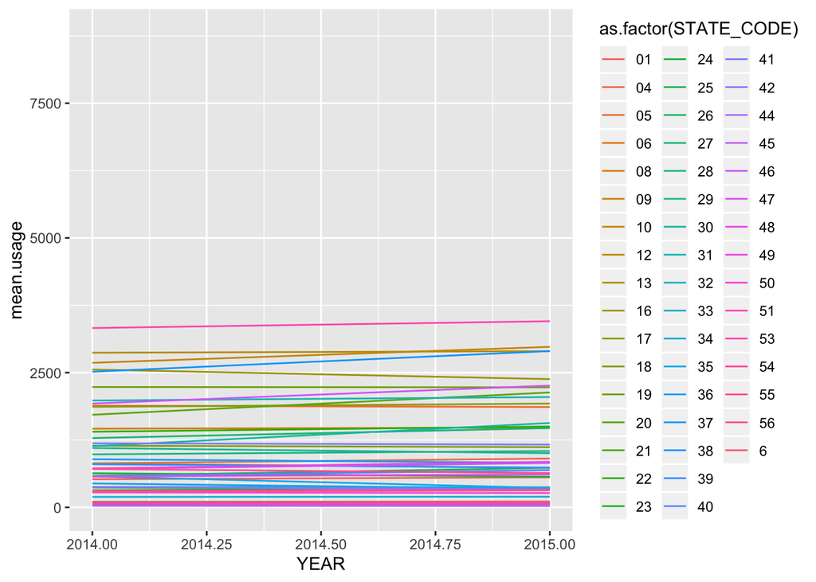

```r
pest.total %>% group_by(STATE_CODE, YEAR) %>%
  summarise(mean.usage = mean(HIGH_ESTIMATE)) %>%
  ungroup() %>%
  add_case(STATE_CODE = 6, YEAR = 2015, mean.usage = 0) %>% ggplot(aes(group = STATE_CODE, color = as.factor(STATE_CODE))) +
  geom_line(aes(x = YEAR, y = mean.usage))
```

Dataset 2 This dataset provides information about vehicle accidents in the UK from 2005 to 2014

1. What fraction of accidents occur in rural areas?

```r
count.by.local <- accidents %>%
  group_by(Urban_or_Rural_Area) %>%
  summarise(number = n())

count.by.local$number[2]/sum(count.by.local$number)
```

```
## [1] 0.3572559
```

```r
rm(count.by.local)
```

2. Do accidents in high-speed-limit areas have more casualties? Compute the Pearson correlation coefficient between the speed limit and the ratio of the number of casualties to accidents for each speed limit. (Group the data by speed limit)

```r
casualties %>%
  right_join(accidents, by = "Accident_Index") %>%
  group_by(Speed_limit) %>%
  summarise(casualties.per.speed = n()) %>%
  ungroup() %>%
  summarise(p.cor = cor(casualties.per.speed, Speed_limit))
```

```
## # A tibble: 1 x 1
##   p.cor
##   <dbl>
## 1 0.111
```

3. When is the most dangerous time to drive? Find the hour of the day that has the highest occurance of fatal accidents, normalized by the total number of accidents that occured in that hour (compute the corresponding frequency of fatal accidents to all accidents in that hour). Note: round accident times down. For example, if an accident occured at 23:55 it occured in hour 23

```r
accidents$Time <- hour(strptime(accidents$Time, format = "%H:%M"))
casualties %>%
  right_join(accidents, by = "Accident_Index") %>%
  group_by(Time, Casualty_Severity) %>%
  summarise(accidents.by.severity = n()) %>%
  group_by(Time) %>% summarise(fatalities = accidents.by.severity[1], normalised = fatalities/sum(accidents.by.severity)) %>% arrange(desc(normalised))
```

```
## # A tibble: 25 x 3
##     Time fatalities normalised
##    <int>      <int>      <dbl>
##  1     4        399     0.0315
##  2     3        486     0.0286
##  3     2        591     0.0278
##  4     5        475     0.0275
##  5     1        676     0.0255
##  6     0        853     0.0236
##  7    23        965     0.0190
##  8     6        615     0.0172
##  9    22       1064     0.0169
## 10    21       1024     0.0143
## # … with 15 more rows
```

4. Is there a linear treand in the number of accidents that occured each year? Return the slope in units of increased number of accidents per year

```r
accidents$Date <- as.numeric(str_sub(accidents$Date, 7))

accidents.per.year <- accidents %>% group_by(Date) %>% summarise(accidents = n())
lm(accidents ~ Date, accidents.per.year)
```

```
##
## Call:
## lm(formula = accidents ~ Date, data = accidents.per.year)
##
## Coefficients:
## (Intercept)         Date
##    13249376        -6512
```

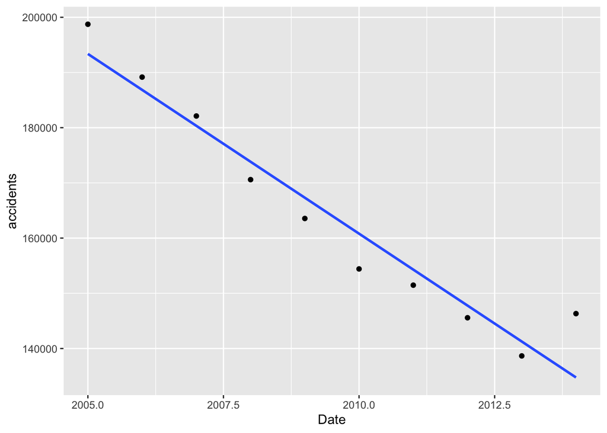

```r
accidents.per.year %>% ggplot(aes(x = Date, y = accidents)) + geom_point() + geom_smooth(method = "lm", se = F)
```

5. How many times more likely are accidents involving male car drivers to be fatal compared to accidents involving female car drivers? Report your answer as the ratio of fatality rates of males to females. Ignore all accidents where the driver wasn’t driving a car.

```r
casualties %>%
  right_join(vehicles, by = "Accident_Index") %>%
  filter(Sex_of_Driver == 1 | Sex_of_Driver == 2) %>%
  filter(Vehicle_Type == 9) %>%
  group_by(Sex_of_Driver, Casualty_Severity) %>%
  summarise(severity.by.sex = n()) %>% group_by(Sex_of_Driver) %>%
  summarise(fatalities = severity.by.sex[1], ratio = fatalities/sum(severity.by.sex))
```

```
## # A tibble: 2 x 3
##   Sex_of_Driver fatalities   ratio
##           <int>      <int>   <dbl>
## 1             1      19381 0.00993
## 2             2       6498 0.00559
```

6. How fast do the number of car accidents drop off with age? Only consider car drivers who are legally allowed to drive in the UK (17 years and older). Find the rate at which the number of accidents exponentially decays with age. Age is measured in years. Assume that the number of accidents is exponentially distributed with age for the drivers over the age of 17?

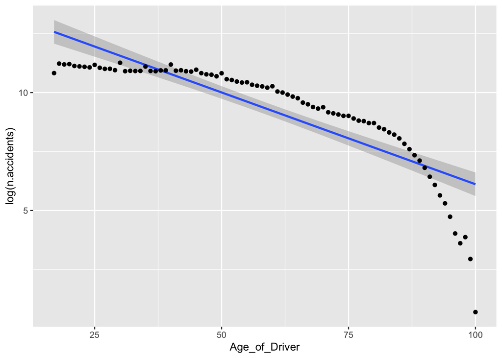

```r
accidents.by.age <- vehicles %>%
  filter(Age_of_Driver > 16) %>% ## Remove drivers too young to legally drive
  group_by(Age_of_Driver) %>%
  summarise(n.accidents = n())
accidents.by.age %>%
  ggplot(aes(y = log(n.accidents), x = Age_of_Driver)) +
  geom_smooth(method = "lm") + geom_point()
```

```r
summary(lm(formula = log(n.accidents) ~ Age_of_Driver, data = accidents.by.age))
```

```
##
## Call:
## lm(formula = log(n.accidents) ~ Age_of_Driver, data = accidents.by.age)
##
## Residuals:
##     Min      1Q  Median      3Q     Max
## -5.4199 -0.6611  0.4913  0.8375  1.0413
##
## Coefficients:
##                Estimate Std. Error t value Pr(>|t|)
## (Intercept)   13.898150   0.331485   41.93   <2e-16 ***
## Age_of_Driver -0.077851   0.005235  -14.87   <2e-16 ***
## ---
## Signif. codes:  0 '***' 0.001 '**' 0.01 '*' 0.05 '.' 0.1 ' ' 1
##
## Residual standard error: 1.163 on 82 degrees of freedom
## Multiple R-squared:  0.7295, Adjusted R-squared:  0.7262
## F-statistic: 221.2 on 1 and 82 DF,  p-value: < 2.2e-16
```

7. How many times more likely are you to be in an accident where you skid, jackknife, or overturn (as opposed to an accident where you don’t) when it’s raining or snowing compared to nice weather with no high winds? Ignore accients where the weather is unknown or missing

```r
bad.weather <- c(2, 3, 5, 6) ## the codes for rain and snow in no wind (2, 3) and high wind (5, 6)
good.weather <- 1 ## code for fine weather no high wind
spec.accident <- c(1:5) ## The specified accidents (skid, jackknife, overturn)

accidents %>%
  right_join(vehicles, by = "Accident_Index") %>%
  mutate(binary.weather = ifelse(Weather_Conditions == good.weather, yes = 0, ## create a new variable, binary.weather, which indicates if the weather is fair (0) or in the list (1) else (2) to be removed.
                                 no = ifelse(Weather_Conditions %in% bad.weather, yes = 1,
                                        no = 2)),
         binary.accident = ifelse(Skidding_and_Overturning %in% spec.accident, yes = 1, no = 0)) %>% # create a new var, binary.accident, that indicates if the accident was one specified (1) or a different kind of accident (0)
  filter(binary.weather != 2) %>% #removes weather conditions that don't match our expectations
  group_by(binary.weather, binary.accident) %>%
  summarise(n.accidents = n()) %>% group_by(binary.weather) %>% ## Total number of accidents grouped by weather condition and accident type
  summarise(probability = n.accidents[2]/n.accidents[1]) %>% ## calculate the probability of having a specified accident grouped by weather
  ungroup() %>% summarise(times.as.likely = probability[2]/probability[1]) ## calculate how many more times likely you are to be in that accident depending on the weather
```

```
## # A tibble: 1 x 1
##   times.as.likely
##             <dbl>
## 1            1.99
```